## This assignment may be worked individually or in pairs.

## Enter your name/names here:

```python
#names here
# Jacob Zillifro

#please give this program a while to run(it takes an hour on my laptop)
#late days used: 2
```

# Assignment 2: Naive Bayes and KNN classifier

In this assignment you'll implement the Naive Bayes and KNN classifier to classify patients as either having or not having diabetic retinopathy. For this task we'll be using the same Diabetic Retinopathy data set which was used in the previous assignment on decision trees. The implementation details are up to you but, generally it is a good idea to divide your code up into helper functions.

```python
# Standard Headers
# You are welcome to add additional headers if you wish
# EXCEPT for scikit-learn... You may NOT use scikit-learn for this assignment!
import pandas as pd
import numpy as np
import matplotlib.pyplot as plt
from math import log, sqrt
from random import shuffle
```

```python
class DataPoint:
    def __str__(self):
        return "< " + str(self.label) + ": " + str(self.features) + " >"
    def __init__(self, label, features):
        self.label = label # the classification label of this data point
        self.features = features
```

Read the data from a CSV file. You may either put it into a list of `DataPoints` as you did on the previous assignment (class provided above), or you may choose to store it any any format you wish, like a Pandas dataframe, or any other format you'd like.

```python
def get_data(filename):
    data = []
#     your code goes here
    df = pd.read_csv(filename, header=None, names=[i for i in range(20)])
    return df
```

```python
df = get_data("messidor_features.txt")
df.head()
```

|  | 0 | 1 | 2 | 3 | 4 | 5 | 6 | 7 | 8 | 9 | 10 | 11 | 12 | 13 | 14 | 15 | 16 | 17 | 18 | 19 |
| --- | --- | --- | --- | --- | --- | --- | --- | --- | --- | --- | --- | --- | --- | --- | --- | --- | --- | --- | --- | --- |
| 0 | 1 | 1 | 22 | 22 | 22 | 19 | 18 | 14 | 49.895756 | 17.775994 | 5.270920 | 0.771761 | 0.018632 | 0.006864 | 0.003923 | 0.003923 | 0.486903 | 0.100025 | 1 | 0 |
| 1 | 1 | 1 | 24 | 24 | 22 | 18 | 16 | 13 | 57.709936 | 23.799994 | 3.325423 | 0.234185 | 0.003903 | 0.003903 | 0.003903 | 0.003903 | 0.520908 | 0.144414 | 0 | 0 |
| 2 | 1 | 1 | 62 | 60 | 59 | 54 | 47 | 33 | 55.831441 | 27.993933 | 12.687485 | 4.852282 | 1.393889 | 0.373252 | 0.041817 | 0.007744 | 0.530904 | 0.128548 | 0 | 1 |
| 3 | 1 | 1 | 55 | 53 | 53 | 50 | 43 | 31 | 40.467228 | 18.445954 | 9.118901 | 3.079428 | 0.840261 | 0.272434 | 0.007653 | 0.001531 | 0.483284 | 0.114790 | 0 | 0 |
| 4 | 1 | 1 | 44 | 44 | 44 | 41 | 39 | 27 | 18.026254 | 8.570709 | 0.410381 | 0.000000 | 0.000000 | 0.000000 | 0.000000 | 0.000000 | 0.475935 | 0.123572 | 0 | 1 |

## Part 1: Naive Bayes Classifier

Naive Bayes (NB) classifier is a simple probabilistic classifier that is based on applying the Bayes' theorem and assumes a strong (naive) independence between features. The Diabetic Retinopath data set contains both categorical and continuous features. Dealing with categorical features has been already been discussed in detail in class. Continuous attributes, on the other hand, are more interesting to handle. Most commonly, this is done by assuming normal probability distribution over the feature values or by binning the attribute values in a fixed number of bins. In this assignment you'll be implementing the binning approach. For each continuous attribute, you'll construct 3 equal sized bins. For example, feature 5 ranges from `[1 - 120]` the 3 bins that you'll construct will be `[1 - 40]`, `[41 - 80]`, `[81 - 120]`.

```python
# your code goes here
class NB:
    def __init__(self, df):
        vc = df[19].value_counts()
        num_p = vc[1]
        num_n = vc[0]

        self.num_p = num_p
        self.num_n = num_n

        thresh = []
        for i in range(19):
            min_val = df[i].min()
            max_val = df[i].max()
            third = (max_val-min_val)/3
            t1 = min_val + third
            t2 = min_val + third*2
            thresh.append([t1, t2])

        self.thresh = thresh

        p_counts = []
        p_df = df[df[19] == 1]
        for i in range(19):
            low = p_df[p_df[i] <= thresh[i][0]].count()[0]
            mid = p_df[(p_df[i] > thresh[i][0]) & (p_df[i] <= thresh[i][1])].count()[0]
            hi = p_df[p_df[i] > thresh[i][1]].count()[0]
            p_counts.append([low, mid, hi])

        self.p_counts = p_counts

        n_counts = []
        n_df = df[df[19] == 0]
        for i in range(19):
            low = n_df[n_df[i] <= thresh[i][0]].count()[0]
            mid = n_df[(n_df[i] > thresh[i][0]) & (n_df[i] <= thresh[i][1])].count()[0]
            hi = n_df[n_df[i] > thresh[i][1]].count()[0]
            n_counts.append([low, mid, hi])

        self.n_counts = n_counts

    def predict(self, row):
        f_given_p = 1
        f_given_n = 1
        for i, feat in enumerate(row[:19]):
            bin_index = 1
            if feat > self.thresh[i][1]:
                bin_index = 2
            elif feat < self.thresh[i][0]:
                bin_index = 0
            p_count = self.p_counts[i][bin_index]
            n_count = self.n_counts[i][bin_index]
            fi_given_p = (p_count/self.num_p)
            fi_given_n = (n_count/self.num_n)
            f_given_p *= fi_given_p
            f_given_n *= fi_given_n
        total = self.num_p + self.num_n
        prob_p = self.num_p/total
        prob_n = self.num_n/total

        p_given_f = f_given_p * prob_p
        n_given_f = f_given_n * prob_n

        if p_given_f >= n_given_f:
            return 1
        return 0
```

```python
def k_fold_validate(k, model, df, hp=None):
    fold_size = int((df.count()[0])/k)
    acc_sum = 0
    for i in range(k):
        test = df[i*fold_size: i*fold_size+fold_size]
        test.drop
        train = pd.concat([df[:i*fold_size], df[i*fold_size+fold_size:]])
        classifier = None
        if hp is None:
            classifier = model(train)
        else:
            classifier = model(train, hp)
        correct = 0
        total = 0
        for i, row in test.iterrows():
            truth = row[19]
            row = row[:19]
            prediction = classifier.predict(row)
            if prediction == truth:
                correct+=1
            total+=1
        acc = 100*(correct/total)
        acc_sum += acc
    avg_accuracy = acc_sum/k
    return avg_accuracy

k_fold_validate(5,NB, df)
```

```
59.04347826086956
```

## Part 2: K Nearest Neighbor (KNN) Classifier

The KNN classifier consists of two stages:-

- In the training stage, the classifier takes the training data and simply memorizes it
- In the test stage, the classifier compares the test data with the training data and simply returns the maximum occuring label of the k nearest data points.

The distance calculation method is central to the algorithm, typically Euclidean distance is used but other distance metrics like Manhattan distance can also be used. In this assignment you'll be implementing the classifier using the Euclidean distance metric. It is important to note that, Euclidean distance is very sensitive to the scaling of different attributes hence, before you can build your classifier you have to normalize the values of each feature in the data set.

Q2. Normalize the dataset so that each feature value lies between `[0-1]`.

```python
# your code goes here
dfn = ((df-df.min())/(df.max()-df.min()))
dfn.head()
```

|  | 0 | 1 | 2 | 3 | 4 | 5 | 6 | 7 | 8 | 9 | 10 | 11 | 12 | 13 | 14 | 15 | 16 | 17 | 18 | 19 |
| --- | --- | --- | --- | --- | --- | --- | --- | --- | --- | --- | --- | --- | --- | --- | --- | --- | --- | --- | --- | --- |
| 0 | 1.0 | 1.0 | 0.140000 | 0.160305 | 0.176471 | 0.173077 | 0.177083 | 0.147727 | 0.122764 | 0.106359 | 0.049693 | 0.012913 | 0.000362 | 0.000342 | 0.000661 | 0.001271 | 0.530801 | 0.261133 | 1.0 | 0.0 |
| 1 | 1.0 | 1.0 | 0.153333 | 0.175573 | 0.176471 | 0.163462 | 0.156250 | 0.136364 | 0.142126 | 0.142403 | 0.031351 | 0.003918 | 0.000076 | 0.000194 | 0.000657 | 0.001264 | 0.682302 | 0.536341 | 0.0 | 0.0 |
| 2 | 1.0 | 1.0 | 0.406667 | 0.450382 | 0.487395 | 0.509615 | 0.479167 | 0.363636 | 0.137472 | 0.167497 | 0.119614 | 0.081188 | 0.027106 | 0.018571 | 0.007043 | 0.002509 | 0.726836 | 0.437973 | 0.0 | 1.0 |
| 3 | 1.0 | 1.0 | 0.360000 | 0.396947 | 0.436975 | 0.471154 | 0.437500 | 0.340909 | 0.099403 | 0.110368 | 0.085971 | 0.051525 | 0.016340 | 0.013555 | 0.001289 | 0.000496 | 0.514678 | 0.352675 | 0.0 | 0.0 |
| 4 | 1.0 | 1.0 | 0.286667 | 0.328244 | 0.361345 | 0.384615 | 0.395833 | 0.295455 | 0.043799 | 0.051281 | 0.003869 | 0.000000 | 0.000000 | 0.000000 | 0.000000 | 0.000000 | 0.481936 | 0.407122 | 0.0 | 1.0 |

Q3. Build your KNN classifier.

```python
# your code goes here
class KNN:
    def __init__(self, df, k):
        self.data = df
        self.k = k

    def predict(self, row):
        dist_data = self.data.apply(lambda row2: self.euclidean_distance(row, row2), axis=1)
        label_sum = 0
        for i in range(self.k):
            row_label = dist_data.idxmin()
            label_sum += self.data.loc[row_label][19]
            dist_data.drop(row_label, inplace=True)
        if label_sum > self.k/2:
            return 1
        return 0

    def euclidean_distance(self, row1, row2):
        s = 0
        for i in range(len(row1)):
            a = row1[i]-row2[i]
            s += a*a
        return sqrt(s)
```

Q4. Find the best value of k using 5-fold cross validation. In each fold of CV, divide your data into a training set and a validation set. Try k ranging from 1 to 10 and plot the accuracies using 5-fold CV. Use this plot to identify the best value of k (provide reasoning).

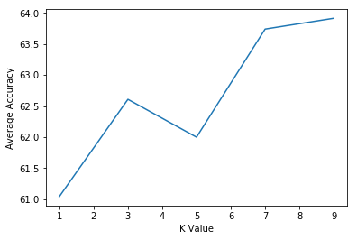

```
The best k value is: 9
```

```
9
```

```python
# your code goes here
def find_best_k(data):
    k_list = []
    acc_list = []
    max_acc = 0
    max_k = 1
    for k in range(1,10,2):
        acc = k_fold_validate(5,KNN, data, k)
        if acc > max_acc:
            max_acc = acc
            max_k = k
        k_list.append(k)
        acc_list.append(acc)
    plt.plot(k_list, acc_list)
    plt.ylabel('Average Accuracy')
    plt.xlabel('K Value')
    plt.show()
    print("The best k value is: " + str(max_k))
    return max_k
find_best_k(dfn)
```

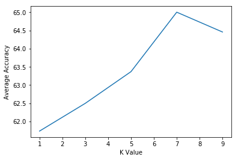

```
The best k value is: 7
```

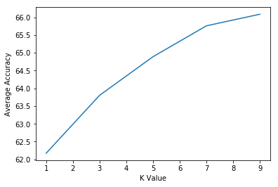

```
The best k value is: 9
```

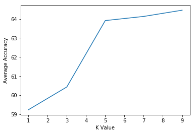

```
The best k value is: 9
```

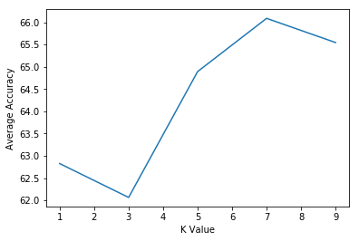

```
The best k value is: 7
```

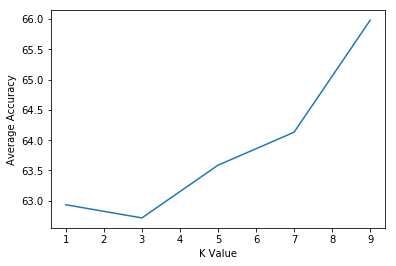

```
The best k value is: 9
average accuracy: 64.78260869565217
```

```python
# your code goes here
def cross_validate_knn(k):
    fold_size = int((df.count()[0])/k)
    acc_sum = 0
    for i in range(k):
        test = df[i*fold_size: i*fold_size+fold_size]
        test.drop
        train = pd.concat([df[:i*fold_size], df[i*fold_size+fold_size:]])
        best_k = find_best_k(train)
        knn = KNN(train, best_k)
        correct = 0
        total = 0
        for i, row in test.iterrows():
            truth = row[19]
            row = row[:19]
            prediction = knn.predict(row)
            if prediction == truth:
                correct+=1
            total+=1
        acc = 100*(correct/total)
        acc_sum += acc
    avg_accuracy = acc_sum/k
    print("average accuracy: " + str(avg_accuracy))
cross_validate_knn(5)
```

### To explore further:

1) Use scikit-learn's NearestNeighbor classifier to classify the data. Compare those results to your own. The documentation can be found [here](http://scikit-learn.org/stable/modules/neighbors.html), specifically section 1.6.2 and the link to the KNeighborsClassifier.

2) Use scikit-learn's Naive Bayes classifier to classify the data. Compare those results to your own. The documentation is found [here](http://scikit-learn.org/stable/modules/naive_bayes.html), specifically section 1.9.2 and the link to MultinomialNB. You will want to bin the continuous attributes, as you did above, and consider each bin to be a categorical value for that attribute. For example, feature 5 ranges from [1 - 120], and the 3 bins that you'll construct will be [1 - 40], [41 - 80], [81 - 120]. You can think of this as saying that feature 5 can take 1 of 3 values: low, med, or high. With binning, you have transformed all of your features into categorical features and the MultinomialNB version of Naive Bayes is what should be used for all categorical data.